Name-Nisarg Patel student id-8878184

-Performance Metrics for Classification

-Classification

-The task of determining which of a number of categories (sub-populations) an observation (or observations) belongs to is known as classification in statistics and machine learning. Examples include classifying an email as "spam" or "non-spam" and diagnosing a patient based on observed traits (such as blood pressure, sex, or the presence or absence of specific symptoms).

-The individual observations are frequently broken down into a collection of quantitative characteristics, also referred to as features or explanatory factors. Different types of attributes exist, such as categorical (like "A", "B", "AB", or "O" for blood types), ordinal (like "large", "medium", or "small"), integer-valued (like the quantity of a specific word in an email), or real-valued (like a blood pressure measurement).

-A classifier is an algorithm that does classification, particularly in a concrete implementation. There are situations when the word "classifier" also refers to the mathematical operation that a classification algorithm does to translate input data to a category.

-What are we trying to solve in a classification problem?

-Predicting or allocating categorical labels to input data points according to their attributes is the aim of a classification issue. The primary goal is to create a model that can accurately categorise fresh, unseen instances into specified classes or categories by learning patterns and correlations within the data.

-What is a classifier?

-Any algorithm that divides data into labelled classes, or informational groups, is called a classifier. Classifiers are defined by a set of dynamic rules that are specific to the kind of inputs they are analysing. These rules include an interpretation process for handling values that are unclear or unknown. Essentially, using labelled training data, the classifier "learns" patterns and correlations and applies this understanding to predict new, unseen instances.

```python
import numpy as np


from matplotlib import pyplot as plt
import matplotlib.patches as patches  # for curved arrows
import seaborn as sns
from sklearn.datasets import fetch_openml
from sklearn.linear_model import SGDClassifier
from sklearn.dummy import DummyClassifier
from sklearn.ensemble import RandomForestClassifier
from sklearn.model_selection import cross_validate, cross_val_predict
from sklearn.metrics import confusion_matrix, precision_score, recall_score, f1_score, precision_recall_curve, roc_curve, roc_auc_score
```

Getting Information The data is loaded from openml.org. Anyone can post open datasets to openml.org, a public repository for machine learning data and experiments.Using the function sklearn.datasets.fetch_openml, the sklearn.datasets package can retrieve datasets from the repository (sklearn User Guide, sklearn documentation).

To the pupil:

Examine the openml website and provide a brief synopsis of its contents based on the main landing page. Go through the first two paragraphs of the MNIST article on Wikipedia. What is the number of images in it? 70,000 (test data = 10,000; train data = 60,000) What dimensions do each image have? Pixels: 28 × 28 (784)

What is the number of unique digits in this dataset according to the sample photos from the MNIST test dataset?

10 (0–9)

To get familiar with sklearn documentaion - browse the sklearn-doc to find out what as_frame stands for

```python
mnist = fetch_openml('mnist_784', as_frame=False)
```

```python
type(mnist)
```

```
sklearn.utils.Bunch
```

```python
list(mnist)
```

```
['data',
 'target',
 'frame',
 'categories',
 'feature_names',
 'target_names',
 'DESCR',
 'details',
 'url']
```

```python
mnist.keys()
```

```
dict_keys(['data', 'target', 'frame', 'categories', 'feature_names', 'target_names', 'DESCR', 'details', 'url'])
```

```python
X = mnist.data
y = mnist.target
```

```python
def plot_digit(image_data):
    image = image_data.reshape(28, 28)
    plt.imshow(image)
    plt.axis("off")
```

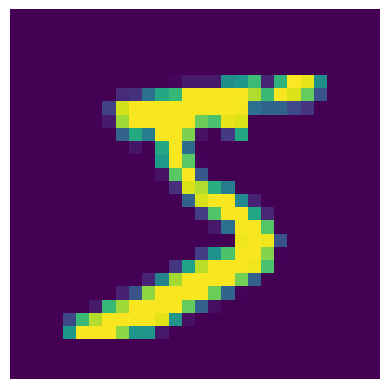

```python
some_digit = X[0]  # here we are using the first image in the dataset
plot_digit(some_digit)
plt.show()
```

```python
y[0]
```

```
'5'
```

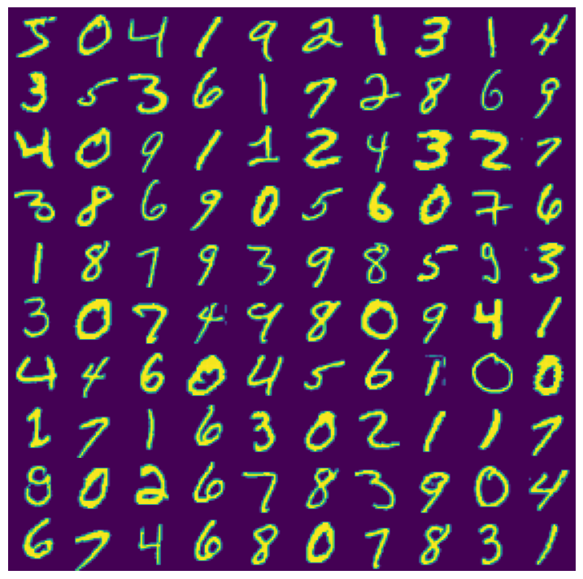

```python
plt.figure(figsize=(9, 9))
for idx, image_data in enumerate(X[:100]):
    plt.subplot(10, 10, idx + 1)
    plot_digit(image_data)
plt.subplots_adjust(wspace=0, hspace=0)
plt.show()
```

```
1    7877
7    7293
3    7141
2    6990
9    6958
0    6903
6    6876
8    6825
4    6824
5    6313
dtype: int64
```

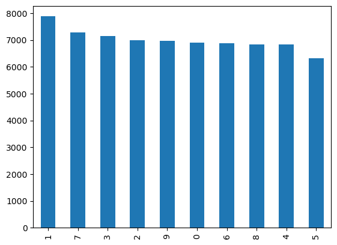

```python
import pandas as pd
labels_count = pd.Series(mnist.target)
labels_count_each =  labels_count.value_counts()
display(labels_count_each)
labels_count_each.plot.bar()
```

-MNIST dataset seems to be almost balanced as the data is ranging from 6,313 to 7,877 samples. Therefore there is minimal skewness in the dataset.

-Preprocessing the Data

```python
X_train, X_test, y_train, y_test = X[:60000], X[60000:], y[:60000], y[60000:]
y_train_5 = (y_train == '5')  # True for all 5s, False for all other digits
y_test_5 = (y_test == '5')
y_train_5[:5]
```

```
array([ True, False, False, False, False])
```

to the student:

-What does the Boolean values (True and False) stand for in the target y_train_5? -The true traget represent the given image in the x_train are 5s and false represents it is not a 5

-Why wasn't X changed as well? -Because it was an independent feature also the purpose was to create boolean labels (True or False) based on the digit labels in the target arrays which do not effect our X data

-Training a Model

```python
sgd_clf = SGDClassifier(random_state=42)
sgd_clf.fit(X_train, y_train_5)

sgd_clf.predict([some_digit])
```

```
array([ True])
```

-To the student:

Which image does some_digit stand for? (scroll above if needed) The some_digit stand for the image value of 5

What is the meaning of the resulting Boolean value (True and False)? if the image value is 5 then the result will be True else False

-Evaluating the Model

-Accuracy Let's start with accuracy as a performance metric. In sklearn, a performance metric is also known as scoring metric, and its value as score.

-Accuracy is the ratio between correct perdictions to all predictions (Wikipedia).

```python
cross_validate(estimator=sgd_clf, X=X_train, y=y_train_5, cv=3, scoring="accuracy")
```

```
{'fit_time': array([7.88008189, 7.3004458 , 5.28254199]),
 'score_time': array([0.02907467, 0.02310634, 0.02296162]),
 'test_score': array([0.95035, 0.96035, 0.9604 ])}
```

Regarding the cross-validate function and the cv argument:

The cv argument in cross-validation describes the number of folds or subsets into which the data is divided for the purpose of cross-validation. It determines how many times the model is trained and evaluated on different portions of the data. Regarding accuracy for the first fold:

In the first fold of cross-validation, the model achieved an accuracy of 95.03%. This means that out of 100 images, the model correctly predicted the labels of 95 images, but it made incorrect predictions on the remaining 5. For achieving 90% accuracy when classifying one digit versus all others (e.g., classifying digit 5 versus all other digits):

A simple rule to achieve 90% accuracy would be to classify an image as the specific digit (e.g., digit 5) if it looks like a 5, and for all other images that don't look like a 5, classify them as not being the specific digit (in this case, not being 5). This rule should result in a high accuracy as long as the model can effectively distinguish the target digit (5) from the others.

```python
dummy_clf = DummyClassifier()
dummy_clf.fit(X_train, y_train_5)
```

```
DummyClassifier()
```

```python
cross_validate(estimator=dummy_clf, X=X_train, y=y_train_5, cv=3, scoring="accuracy")
```

```
{'fit_time': array([0.16840553, 0.16389871, 0.15747476]),
 'score_time': array([0.00101423, 0.00102019, 0.00199509]),
 'test_score': array([0.90965, 0.90965, 0.90965])}
```

To the student:

-What is the accuracy of the DummyClassifier? The Accuracy of the model is 90.96%

-How does it compare to the handwritten rule you suggested above, and to the SGDClassifier? The DummyClassifier have a default argument as prior for strategy which means the models will give the prediction of the output as the most reccuring value in the data . therefore the model is very similar to the handwritten rule. However , SGDClassifier performs much better than DummyClassifier as the SGDClassifier effectively learning patterns and relationships in the dataset

```python
dummy_clf.predict(X_train)
print(any(dummy_clf.predict(X_train)))
print(any(dummy_clf.predict(X_test)))
```

```
False
False
```

This illustration demonstrates how, even while accuracy is a valuable metric, it only discloses a portion of the model's functionality. To get a fuller picture, extra measures ought to be used.

-Confusion Metrix In the field of machine learning and specifically the problem of classification, a confusion matrix, is a specific table layout that allows visualization of the performance of an algorithm, typically a supervised learning one Wikipedia.

To understand what a confusion matrix is, it is useful to start with an example. Wikipedia provides us with a good one, let's go over it together...

In a binary classification, for a single prediction of one sample, there are 4 possible options for the prediction with respect to the target label (5 in our example, the target can be chosen from the two labels, based on our interest, based for instance on the main objective of the classifier):

the positive class is one of the two classes in a binary classification problem. It is the class that the model is trying to predict. The choice of which class is considered positive and which is considered negative is often arbitrary and depends on the context of the problem. For example, in a medical test for a disease, the positive class could be “disease present” and the negative class could be “disease not present”.

There are two types of correct predictions:

True Positive - the prediction is of the target class, and that is correct (according to the ground truth). True Negative - the prediction is not of the target class, and this is correct. There are two types of incorrect predictions:

False Positive - the prediction is of the target class, and this is incorrect (according to the ground truth). False Negative - the prediction is not of the target class, and this is incorrect The confusion matrix is a table:

Each row stands for an actual label (going over all labels in the dataset, one row per label) Each column stands for a predicted label (going over all labels in the dataset, one row per label) Each cell in the table simply counts the number of samples in the dataset that had such a predicted-actual combination. This can be augmented by a percentage, where this number is divided by the total number of samples in the dataset.

```python
y_train_pred = cross_val_predict(sgd_clf, X_train, y_train_5, cv=3)
y_train_pred.shape

y_train_pred[:10]

cm = confusion_matrix(y_train_5, y_train_pred)
cm
cm.sum()
```

```
60000
```

```python
y_train_perfect_predictions = y_train_5
confusion_matrix(y_train_5, y_train_perfect_predictions)
```

```
array([[54579,     0],
       [    0,  5421]], dtype=int64)
```

-Precision and Recall In classification, precision and recall are additional performance metrics (Wikipedia). They are calculated and presented with respect to the 'class of interest'. This class can be any one that we are interested in calculating precision and recall for. It depends on the success criteria that we have defined for the model. For instance, if the model should identify a risk of an illness based on a medical test results, the class of interest would probably be existence of such medical condition. We call this class of interest as the positive class.

The precision and recall image in Wikipedia is an effective way to understand these definitions.

See also SKLearn User Guide

```python
precision_score(y_train_5, y_train_pred)
```

```
0.8370879772350012
```

```python
recall_score(y_train_5, y_train_pred)
```

```
0.6511713705958311
```

F1-score

it can be useful to compare classifiers based on a single number, that encompases both precision and recall. F1-score is a common such performance metrix.

The F-score is calculated from the precision and recall of the test. The F1 score is the harmonic mean of the precision and recall (harmonic mean is the average of rates (Wikipedia), see more below). The highest possible value of an F-score is 1.0, indicating perfect precision and recall, and the lowest possible value is 0, if either precision or recall are zero. (Wikipedia). Whereas the regular (arithmetic) mean treats all values equally, the harmonic mean gives more weight to low values. As a result, the classifier will only get a high F1 score if both recall and precision are high.

Notice that the F1 score is independent of True Negatives (TN) (Wikipedia).

```python
f1_score(y_train_5, y_train_pred)
```

```
0.7325171197343846
```

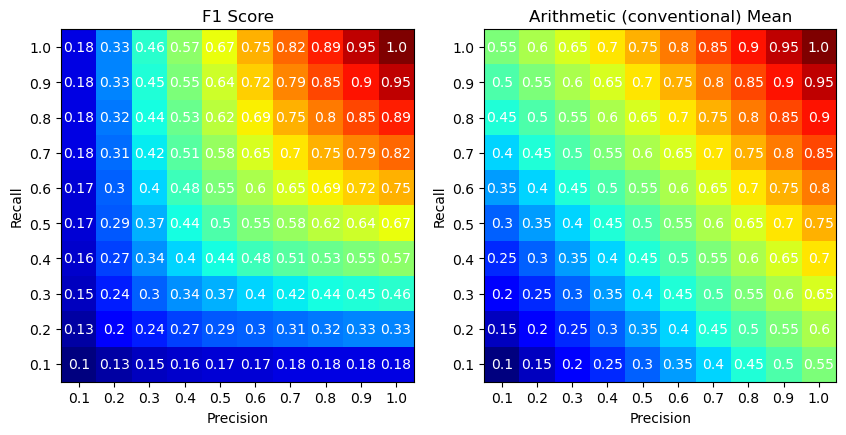

```python
precision = np.round(np.linspace(0.1, 1, 10), 2)
recall = np.round(np.linspace(1, 0.1, 10), 2)

precision_grid, recall_grid = np.meshgrid(precision, recall)

f1_score_calc = np.round(2 * (precision_grid * recall_grid) / (precision_grid + recall_grid), 2)
arithmetic_mean = np.round((precision_grid + recall_grid) / 2, 2)

fig, axes = plt.subplots(figsize=(10, 5), ncols=2)

im1 = axes[0].imshow(f1_score_calc, cmap="jet")
axes[0].set_xticks(np.arange(len(precision)), precision)
axes[0].set_yticks(np.arange(len(recall)), recall)


for i in range(len(precision)):
    for j in range(len(recall)):
        text = axes[0].text(j, i, f1_score_calc[i, j],
                       ha="center", va="center", color="w")
axes[0].set_xlabel("Precision")
axes[0].set_ylabel("Recall")
axes[0].set_title("F1 Score")

im2 = axes[1].imshow(arithmetic_mean, cmap="jet")
axes[1].set_xticks(np.arange(len(precision)), precision)
axes[1].set_yticks(np.arange(len(recall)), recall)

for i in range(len(precision)):
    for j in range(len(recall)):
        text = axes[1].text(j, i, arithmetic_mean[i, j],
                       ha="center", va="center", color="w")
axes[1].set_xlabel("Precision")
axes[1].set_ylabel("Recall")
axes[1].set_title("Arithmetic (conventional) Mean")
```

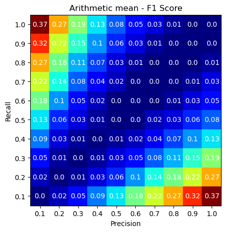

```python
fig, ax = plt.subplots(figsize=(5, 5), ncols=1)

diff = np.round(arithmetic_mean - f1_score_calc, 2)

im1 = ax.imshow(diff, cmap="jet")
ax.set_xticks(np.arange(len(precision)), precision)
ax.set_yticks(np.arange(len(recall)), recall)

for i in range(len(precision)):
    for j in range(len(recall)):
        text = ax.text(j, i, diff[i, j],
                       ha="center", va="center", color="w")
ax.set_xlabel("Precision")
ax.set_ylabel("Recall")
ax.set_title("Arithmetic mean - F1 Score")
```

```python
y_scores = sgd_clf.decision_function([some_digit])
y_scores
```

```
array([2164.22030239])
```

```python
threshold = 0
y_some_digit_pred = (y_scores > threshold)
print(y_some_digit_pred)
```

```
[ True]
```

```python
#Changing the threshold changes the prediction:

threshold = 3000
y_some_digit_pred = (y_scores > threshold)
y_some_digit_pred
```

```
array([False])
```

```python
y_scores = cross_val_predict(sgd_clf, X_train, y_train_5, cv=3, method="decision_function")

precisions, recalls, thresholds = precision_recall_curve(y_train_5, y_scores)
```

```python
print(precisions.shape)
print(recalls.shape)
print(thresholds.shape)
```

```
(59967,)
(59967,)
(59966,)
```

```python
print(precisions[:5])
print(recalls[:5])
print(thresholds[:5])
```

```
[0.09040123 0.09038606 0.09038757 0.09038907 0.09039058]
[1.         0.99981553 0.99981553 0.99981553 0.99981553]
[-106527.45300471 -105763.22240074 -105406.2965229  -104799.72132607
 -104613.21489858]
```

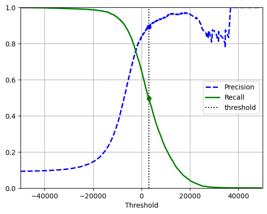

```python
plt.plot(thresholds, precisions[:-1], "b--", label="Precision", linewidth=2)
plt.plot(thresholds, recalls[:-1], "g-", label="Recall", linewidth=2)
plt.vlines(threshold, 0, 1.0, "k", "dotted", label="threshold")
idx = (thresholds >= threshold).argmax()  # first index ≥ threshold
plt.plot(thresholds[idx], precisions[idx], "bo")
plt.plot(thresholds[idx], recalls[idx], "go")
plt.axis([-50000, 50000, 0, 1])
plt.grid()
plt.xlabel("Threshold")
plt.legend(loc="center right")
plt.show()
```

To the student:

What is the intuition behind this behavior? Increasing the threshold means model while predict less positive lower recall and higher precision and Decreasing the threshold means while predict more positive higher recall and lower precision

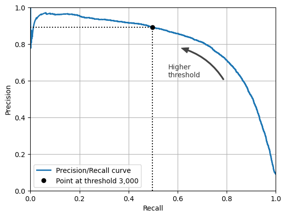

```python
plt.plot(recalls, precisions, linewidth=2, label="Precision/Recall curve")
plt.plot([recalls[idx], recalls[idx]], [0., precisions[idx]], "k:")
plt.plot([0.0, recalls[idx]], [precisions[idx], precisions[idx]], "k:")
plt.plot([recalls[idx]], [precisions[idx]], "ko",
         label="Point at threshold 3,000")
plt.gca().add_patch(patches.FancyArrowPatch(
    (0.79, 0.60), (0.61, 0.78),
    connectionstyle="arc3,rad=.2",
    arrowstyle="Simple, tail_width=1.5, head_width=8, head_length=10",
    color="#444444"))
plt.text(0.56, 0.62, "Higher\nthreshold", color="#333333")
plt.xlabel("Recall")
plt.ylabel("Precision")
plt.axis([0, 1, 0, 1])
plt.grid()
plt.legend(loc="lower left")
plt.show()
```